# Intro to R

Female Code Lab - Greek Girls Code

15/12/2021

# 1 Welcome

Welcome to the Female Code Lab “Intro to R” hands on tutorial delivered by Greek Girls Code.

RStudio is an Integrated Development Environment for R. What does all that mean?  
Well, the term environment is used to characterize a comprehensive and coherent system which allows a user to interact with data. Interaction with data can be done either by using existing “packages” or by develping new methods and tools. Package and tool development has been very dynamic. R is a language, which you can use to interact with data and develop new methods in RStudio. RStudio makes programming in R much easier and we suggest that you use it!

**The tutorial is designed to help you:**

- Familiarize with R and RStudio IDE
- Familiarize with the types of data
- Learn R base functions
- Intro to data transformation with `tidyverse` R package

# 2 Before we start - Participant preparation

To maintain a smooth and timely flow during the “Intro to R” section of the Female Code Lab, each participant must install and set up R, Rstudio and the tidyverse R package before the tutorial.

To do so please follow the instructions bellow:

## 2.1 How to install R

To install R on your computer you can also watch the following video at https://vimeo.com/203516510

## 2.2 How to install RStudio

To install RStudio on your computer please follow the following video at https://vimeo.com/203516968

## 2.3 How to install `tidyverse` R package.

In this section you will learn how to install `tidyverse` but the process is essentially the same for any R package https://vimeo.com/203516241.

`tidyverse` [`{tidyverse}` package](https://www.tidyverse.org/). is compilation or collection of R packages each one designed to transform and visualize data. All `tidyverse` packages implement the same syntax/ grammar in the command line.

To install call the following R function:

```r
install.packages("tidyverse")
```

# 3 Intro to R

*this section includes content from the joint Hellenic Association of Medical Genetics (SIGE)-Greek Girls Code workshop created and delivered by Eirini Tsirvouli* https://eirinits.github.io/

## 3.1 Basic R commands and functionalities

You can use R to perform basic math just as you would do using a calculator! You can just add numbers and get the result

```r
#add numbers
1+2
```

```
## [1] 3
```

```r
#raise to power 6
4^6
```

```
## [1] 4096
```

```r
#create a sequence of numbers (integers) from 1 to 100
seq(1,100)
```

```
##   [1]   1   2   3   4   5   6   7   8   9  10  11  12  13  14  15  16  17  18
##  [19]  19  20  21  22  23  24  25  26  27  28  29  30  31  32  33  34  35  36
##  [37]  37  38  39  40  41  42  43  44  45  46  47  48  49  50  51  52  53  54
##  [55]  55  56  57  58  59  60  61  62  63  64  65  66  67  68  69  70  71  72
##  [73]  73  74  75  76  77  78  79  80  81  82  83  84  85  86  87  88  89  90
##  [91]  91  92  93  94  95  96  97  98  99 100
```

You can use all arithmetic operators for practice

- Try `+`, `-`, `*`, `/`
- Try more complex math e.g. (2+4)^2/5

### 3.1.1 Logical Tests

You can use R to test logical arguments for example

```r
# test if
1/2 == 0.5
```

```
## [1] TRUE
```

```r
# or test if
1/2 > 0.5
```

```
## [1] FALSE
```

### 3.1.2 Data types

https://vimeo.com/220490241

### 3.1.3 Data Structures

A vector is the most basic type of data structure in R. It is essentially a collection of data assigned to a symbol using the assignment operator <- .

```r
# you can assign a single number to a vector x
x<-1
#then call the vector and get the result
x
```

```
## [1] 1
```

```r
# you can assign 1 dimensional data such as string of values
weight<-c(50, 60, 65, 72, 82, 94)
#call weight
weight
```

```
## [1] 50 60 65 72 82 94
```

```r
# you can also get the vector length (number of values contained in the vector)
length(weight)
```

```
## [1] 6
```

```r
# by calling the mode() command you can find out what kind of data the vector holds
mode(weight)
```

```
## [1] "numeric"
```

```r
# you can create a vector with character strings. Important! notice how characters are created using double or single quotes!
days <- c('Sunday', 'Monday', 'Tuesday',
  'Wednesday', 'Thursday', 'Friday',
  'Saturday')

# by calling days you get weekdays
days
```

```
## [1] "Sunday"    "Monday"    "Tuesday"   "Wednesday" "Thursday"  "Friday"
## [7] "Saturday"
```

You can create 2 dimensional vectors by assigning other type of data structure like a **data frame**.

```r
#create a data frame and store it in a vector called df1. The first column will hold numbers 1 to 3 and the second column will hold the 1st 3 letters of the alphabet

df1<-data.frame(numbers=1:3, letters= letters[1:3])
#call df1
df1
```

```
##   numbers letters
## 1       1       a
## 2       2       b
## 3       3       c
```

```r
#find out its structure type (class)
class(df1)
```

```
## [1] "data.frame"
```

```r
# make another data structure by binding vectors of the same length
x<-1:3
y<-letters[1:3]

z<-cbind(x,y)

z
```

```
##      x   y
## [1,] "1" "a"
## [2,] "2" "b"
## [3,] "3" "c"
```

```r
class(z)
```

```
## [1] "matrix" "array"
```

A **data frame** is a 2-dimensional table-like structure which contains columns and rows with variables and values. R includes built-in data sets organized in data frames which you can use to practice. To get a list of the pre-loaded data sets you can call:

```r
data()
```

A popular one is `mtcars`

```r
#call the mtcars data
mtcars
```

```
##                      mpg cyl  disp  hp drat    wt  qsec vs am gear carb
## Mazda RX4           21.0   6 160.0 110 3.90 2.620 16.46  0  1    4    4
## Mazda RX4 Wag       21.0   6 160.0 110 3.90 2.875 17.02  0  1    4    4
## Datsun 710          22.8   4 108.0  93 3.85 2.320 18.61  1  1    4    1
## Hornet 4 Drive      21.4   6 258.0 110 3.08 3.215 19.44  1  0    3    1
## Hornet Sportabout   18.7   8 360.0 175 3.15 3.440 17.02  0  0    3    2
## Valiant             18.1   6 225.0 105 2.76 3.460 20.22  1  0    3    1
## Duster 360          14.3   8 360.0 245 3.21 3.570 15.84  0  0    3    4
## Merc 240D           24.4   4 146.7  62 3.69 3.190 20.00  1  0    4    2
## Merc 230            22.8   4 140.8  95 3.92 3.150 22.90  1  0    4    2
## Merc 280            19.2   6 167.6 123 3.92 3.440 18.30  1  0    4    4
## Merc 280C           17.8   6 167.6 123 3.92 3.440 18.90  1  0    4    4
## Merc 450SE          16.4   8 275.8 180 3.07 4.070 17.40  0  0    3    3
## Merc 450SL          17.3   8 275.8 180 3.07 3.730 17.60  0  0    3    3
## Merc 450SLC         15.2   8 275.8 180 3.07 3.780 18.00  0  0    3    3
## Cadillac Fleetwood  10.4   8 472.0 205 2.93 5.250 17.98  0  0    3    4
## Lincoln Continental 10.4   8 460.0 215 3.00 5.424 17.82  0  0    3    4
## Chrysler Imperial   14.7   8 440.0 230 3.23 5.345 17.42  0  0    3    4
## Fiat 128            32.4   4  78.7  66 4.08 2.200 19.47  1  1    4    1
## Honda Civic         30.4   4  75.7  52 4.93 1.615 18.52  1  1    4    2
## Toyota Corolla      33.9   4  71.1  65 4.22 1.835 19.90  1  1    4    1
## Toyota Corona       21.5   4 120.1  97 3.70 2.465 20.01  1  0    3    1
## Dodge Challenger    15.5   8 318.0 150 2.76 3.520 16.87  0  0    3    2
## AMC Javelin         15.2   8 304.0 150 3.15 3.435 17.30  0  0    3    2
## Camaro Z28          13.3   8 350.0 245 3.73 3.840 15.41  0  0    3    4
## Pontiac Firebird    19.2   8 400.0 175 3.08 3.845 17.05  0  0    3    2
## Fiat X1-9           27.3   4  79.0  66 4.08 1.935 18.90  1  1    4    1
## Porsche 914-2       26.0   4 120.3  91 4.43 2.140 16.70  0  1    5    2
## Lotus Europa        30.4   4  95.1 113 3.77 1.513 16.90  1  1    5    2
## Ford Pantera L      15.8   8 351.0 264 4.22 3.170 14.50  0  1    5    4
## Ferrari Dino        19.7   6 145.0 175 3.62 2.770 15.50  0  1    5    6
## Maserati Bora       15.0   8 301.0 335 3.54 3.570 14.60  0  1    5    8
## Volvo 142E          21.4   4 121.0 109 4.11 2.780 18.60  1  1    4    2
```

```r
#find out its structure type (class)
class(mtcars)
```

```
## [1] "data.frame"
```

```r
# assign the data frame to a vector
cars<-mtcars
#call cars
cars
```

```
##                      mpg cyl  disp  hp drat    wt  qsec vs am gear carb
## Mazda RX4           21.0   6 160.0 110 3.90 2.620 16.46  0  1    4    4
## Mazda RX4 Wag       21.0   6 160.0 110 3.90 2.875 17.02  0  1    4    4
## Datsun 710          22.8   4 108.0  93 3.85 2.320 18.61  1  1    4    1
## Hornet 4 Drive      21.4   6 258.0 110 3.08 3.215 19.44  1  0    3    1
## Hornet Sportabout   18.7   8 360.0 175 3.15 3.440 17.02  0  0    3    2
## Valiant             18.1   6 225.0 105 2.76 3.460 20.22  1  0    3    1
## Duster 360          14.3   8 360.0 245 3.21 3.570 15.84  0  0    3    4
## Merc 240D           24.4   4 146.7  62 3.69 3.190 20.00  1  0    4    2
## Merc 230            22.8   4 140.8  95 3.92 3.150 22.90  1  0    4    2
## Merc 280            19.2   6 167.6 123 3.92 3.440 18.30  1  0    4    4
## Merc 280C           17.8   6 167.6 123 3.92 3.440 18.90  1  0    4    4
## Merc 450SE          16.4   8 275.8 180 3.07 4.070 17.40  0  0    3    3
## Merc 450SL          17.3   8 275.8 180 3.07 3.730 17.60  0  0    3    3
## Merc 450SLC         15.2   8 275.8 180 3.07 3.780 18.00  0  0    3    3
## Cadillac Fleetwood  10.4   8 472.0 205 2.93 5.250 17.98  0  0    3    4
## Lincoln Continental 10.4   8 460.0 215 3.00 5.424 17.82  0  0    3    4
## Chrysler Imperial   14.7   8 440.0 230 3.23 5.345 17.42  0  0    3    4
## Fiat 128            32.4   4  78.7  66 4.08 2.200 19.47  1  1    4    1
## Honda Civic         30.4   4  75.7  52 4.93 1.615 18.52  1  1    4    2
## Toyota Corolla      33.9   4  71.1  65 4.22 1.835 19.90  1  1    4    1
## Toyota Corona       21.5   4 120.1  97 3.70 2.465 20.01  1  0    3    1
## Dodge Challenger    15.5   8 318.0 150 2.76 3.520 16.87  0  0    3    2
## AMC Javelin         15.2   8 304.0 150 3.15 3.435 17.30  0  0    3    2
## Camaro Z28          13.3   8 350.0 245 3.73 3.840 15.41  0  0    3    4
## Pontiac Firebird    19.2   8 400.0 175 3.08 3.845 17.05  0  0    3    2
## Fiat X1-9           27.3   4  79.0  66 4.08 1.935 18.90  1  1    4    1
## Porsche 914-2       26.0   4 120.3  91 4.43 2.140 16.70  0  1    5    2
## Lotus Europa        30.4   4  95.1 113 3.77 1.513 16.90  1  1    5    2
## Ford Pantera L      15.8   8 351.0 264 4.22 3.170 14.50  0  1    5    4
## Ferrari Dino        19.7   6 145.0 175 3.62 2.770 15.50  0  1    5    6
## Maserati Bora       15.0   8 301.0 335 3.54 3.570 14.60  0  1    5    8
## Volvo 142E          21.4   4 121.0 109 4.11 2.780 18.60  1  1    4    2
```

Other data structures include:

- lists , 1-D structure
- matrices, 2-D structures of homogeneous data
- arrays, multiple dimensions of homogeneous data

### 3.1.4 Constructing and manipulating vectors and data frames: R base functions

We can construct a 1-D vector and apply several functions on it. We can also extract elements based on pre-defined criteria.

```r
# construct a 1-D vector
treatment_dose <- c("90mg","40mg","20mg","90mg","20mg")
# get the type
mode(treatment_dose)
```

```
## [1] "character"
```

```r
# get the 1st value in the sequence of values
treatment_dose[1]
```

```
## [1] "90mg"
```

```r
# we can add a new value to the vextor

treatment_dose_plus<- c(treatment_dose, "25mg")

treatment_dose_plus
```

```
## [1] "90mg" "40mg" "20mg" "90mg" "20mg" "25mg"
```

```r
# or we can subtract a value from the vector

treatment_dose_minus<-treatment_dose[-1]

treatment_dose_minus
```

```
## [1] "40mg" "20mg" "90mg" "20mg"
```

```r
#you can extract elements from vectors  holding numeric and character data types by using [ ] or [[]]

treatment_dose[1:3]
```

```
## [1] "90mg" "40mg" "20mg"
```

```r
weekdays <- days[2:6]

weekdays
```

```
## [1] "Monday"    "Tuesday"   "Wednesday" "Thursday"  "Friday"
```

```r
weekdays[[2]]
```

```
## [1] "Tuesday"
```

```r
weekend <- days[c(1, 7)]

weekend
```

```
## [1] "Sunday"   "Saturday"
```

```r
v <- c(1,2,3,4,5)

v[1:3]
```

```
## [1] 1 2 3
```

```r
#you can also run logical tests
v>2
```

```
## [1] FALSE FALSE  TRUE  TRUE  TRUE
```

```r
#you can run length() to obtain the number of data your vector holds even if your data is type="character"
length(days)
```

```
## [1] 7
```

or we can assign a data frame to a vector and extract information based on our predefined criteria

```r
#get the dimensions of mtcars
dim(mtcars)
```

```
## [1] 32 11
```

```r
# get the first 6 rows of mtcras
head(mtcars)
```

```
##                    mpg cyl disp  hp drat    wt  qsec vs am gear carb
## Mazda RX4         21.0   6  160 110 3.90 2.620 16.46  0  1    4    4
## Mazda RX4 Wag     21.0   6  160 110 3.90 2.875 17.02  0  1    4    4
## Datsun 710        22.8   4  108  93 3.85 2.320 18.61  1  1    4    1
## Hornet 4 Drive    21.4   6  258 110 3.08 3.215 19.44  1  0    3    1
## Hornet Sportabout 18.7   8  360 175 3.15 3.440 17.02  0  0    3    2
## Valiant           18.1   6  225 105 2.76 3.460 20.22  1  0    3    1
```

```r
# get the column names
colnames(mtcars)
```

```
##  [1] "mpg"  "cyl"  "disp" "hp"   "drat" "wt"   "qsec" "vs"   "am"   "gear"
## [11] "carb"
```

```r
#get the rownames of mtcars
rownames(mtcars)
```

```
##  [1] "Mazda RX4"           "Mazda RX4 Wag"       "Datsun 710"
##  [4] "Hornet 4 Drive"      "Hornet Sportabout"   "Valiant"
##  [7] "Duster 360"          "Merc 240D"           "Merc 230"
## [10] "Merc 280"            "Merc 280C"           "Merc 450SE"
## [13] "Merc 450SL"          "Merc 450SLC"         "Cadillac Fleetwood"
## [16] "Lincoln Continental" "Chrysler Imperial"   "Fiat 128"
## [19] "Honda Civic"         "Toyota Corolla"      "Toyota Corona"
## [22] "Dodge Challenger"    "AMC Javelin"         "Camaro Z28"
## [25] "Pontiac Firebird"    "Fiat X1-9"           "Porsche 914-2"
## [28] "Lotus Europa"        "Ford Pantera L"      "Ferrari Dino"
## [31] "Maserati Bora"       "Volvo 142E"
```

```r
#subset the first 2 columns of the dataframe
mt.sub1<-mtcars[,1:2]
mt.sub1
```

```
##                      mpg cyl
## Mazda RX4           21.0   6
## Mazda RX4 Wag       21.0   6
## Datsun 710          22.8   4
## Hornet 4 Drive      21.4   6
## Hornet Sportabout   18.7   8
## Valiant             18.1   6
## Duster 360          14.3   8
## Merc 240D           24.4   4
## Merc 230            22.8   4
## Merc 280            19.2   6
## Merc 280C           17.8   6
## Merc 450SE          16.4   8
## Merc 450SL          17.3   8
## Merc 450SLC         15.2   8
## Cadillac Fleetwood  10.4   8
## Lincoln Continental 10.4   8
## Chrysler Imperial   14.7   8
## Fiat 128            32.4   4
## Honda Civic         30.4   4
## Toyota Corolla      33.9   4
## Toyota Corona       21.5   4
## Dodge Challenger    15.5   8
## AMC Javelin         15.2   8
## Camaro Z28          13.3   8
## Pontiac Firebird    19.2   8
## Fiat X1-9           27.3   4
## Porsche 914-2       26.0   4
## Lotus Europa        30.4   4
## Ford Pantera L      15.8   8
## Ferrari Dino        19.7   6
## Maserati Bora       15.0   8
## Volvo 142E          21.4   4
```

```r
#subset the 1st 2 rows and the first 2 columns
mt.sub2<-mtcars[1:2, 1:2]
mt.sub2
```

```
##               mpg cyl
## Mazda RX4      21   6
## Mazda RX4 Wag  21   6
```

### 3.1.5 Transforming and filtering a dataframe with `tidyverse`

Tidyverse is a collection of packages essential to data science and analysis. By loading the package you’ll see each package contained in the collection. We will demonstrate a couple of `dplyr` functions for mutating and filtering data from the `mtcars` data frame. This data frame contains columns with numeric data. `dplyr` can mutate and filter data from heterogeneous data frames with columns of numeric and character data but this will be demonstrated in the next more advanced tutorial by Irene-Angelica Chounta.

```r
library(tidyverse)
#multiply mpg with cyl and add the result in a new column named prod

#first we need to transform the rownames into a column named "name"
mtcars.new<-rownames_to_column(mtcars, var="name")
head(mtcars.new)
```

```
##                name  mpg cyl disp  hp drat    wt  qsec vs am gear carb
## 1         Mazda RX4 21.0   6  160 110 3.90 2.620 16.46  0  1    4    4
## 2     Mazda RX4 Wag 21.0   6  160 110 3.90 2.875 17.02  0  1    4    4
## 3        Datsun 710 22.8   4  108  93 3.85 2.320 18.61  1  1    4    1
## 4    Hornet 4 Drive 21.4   6  258 110 3.08 3.215 19.44  1  0    3    1
## 5 Hornet Sportabout 18.7   8  360 175 3.15 3.440 17.02  0  0    3    2
## 6           Valiant 18.1   6  225 105 2.76 3.460 20.22  1  0    3    1
```

```r
mtcars.mut<-mtcars.new %>% mutate (name, prod = (mpg*cyl) )
mtcars.mut
```

```
##                   name  mpg cyl  disp  hp drat    wt  qsec vs am gear carb
## 1            Mazda RX4 21.0   6 160.0 110 3.90 2.620 16.46  0  1    4    4
## 2        Mazda RX4 Wag 21.0   6 160.0 110 3.90 2.875 17.02  0  1    4    4
## 3           Datsun 710 22.8   4 108.0  93 3.85 2.320 18.61  1  1    4    1
## 4       Hornet 4 Drive 21.4   6 258.0 110 3.08 3.215 19.44  1  0    3    1
## 5    Hornet Sportabout 18.7   8 360.0 175 3.15 3.440 17.02  0  0    3    2
## 6              Valiant 18.1   6 225.0 105 2.76 3.460 20.22  1  0    3    1
## 7           Duster 360 14.3   8 360.0 245 3.21 3.570 15.84  0  0    3    4
## 8            Merc 240D 24.4   4 146.7  62 3.69 3.190 20.00  1  0    4    2
## 9             Merc 230 22.8   4 140.8  95 3.92 3.150 22.90  1  0    4    2
## 10            Merc 280 19.2   6 167.6 123 3.92 3.440 18.30  1  0    4    4
## 11           Merc 280C 17.8   6 167.6 123 3.92 3.440 18.90  1  0    4    4
## 12          Merc 450SE 16.4   8 275.8 180 3.07 4.070 17.40  0  0    3    3
## 13          Merc 450SL 17.3   8 275.8 180 3.07 3.730 17.60  0  0    3    3
## 14         Merc 450SLC 15.2   8 275.8 180 3.07 3.780 18.00  0  0    3    3
```

[output cut: 51 more lines]

```r
# now we want to select the name, mpg , cyl and the prod columns and remove all other columns
mtcars.mut<-mtcars.mut %>% select(name:cyl,prod)
mtcars.mut
```

```
##                   name  mpg cyl  prod
## 1            Mazda RX4 21.0   6 126.0
## 2        Mazda RX4 Wag 21.0   6 126.0
## 3           Datsun 710 22.8   4  91.2
## 4       Hornet 4 Drive 21.4   6 128.4
## 5    Hornet Sportabout 18.7   8 149.6
## 6              Valiant 18.1   6 108.6
## 7           Duster 360 14.3   8 114.4
## 8            Merc 240D 24.4   4  97.6
## 9             Merc 230 22.8   4  91.2
## 10            Merc 280 19.2   6 115.2
## 11           Merc 280C 17.8   6 106.8
## 12          Merc 450SE 16.4   8 131.2
## 13          Merc 450SL 17.3   8 138.4
## 14         Merc 450SLC 15.2   8 121.6
```

[output cut: 18 more lines]

## 3.2 Data Plots

In sections 3.1.4 and 3.1.5 you were introduced in data frames holding large and heterogeneous data. How do we extract and present summarized information from a large collection of data?

The most effective way to distill the essence of data is to represent them graphically or as we say ‘plot’ the data. Graphic data representation or data plotting is often called data visualization. Data visualization helps us reveal patterns or trends that are not immediately visible in raw data e.g.collected in a data frame.

By plotting data we can find relationships in the data and we can communicate our findings in an effective and useful way.

### 3.2.1 base

R base plotting functions

One of the most frequently used plotting functions in R is the plot() function.

[output not shown]

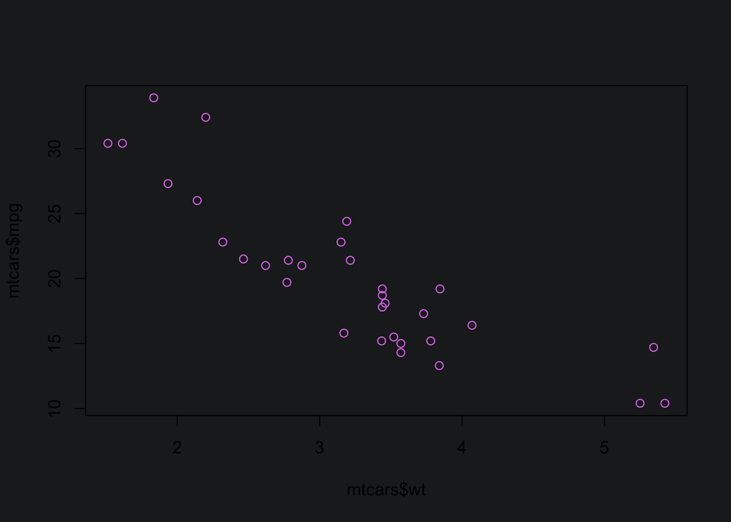

```r
plot(x=mtcars$wt, y=mtcars$mpg, col = thematic::thematic_get_option("accent"))
```

### 3.2.2 ggplot2

```r
install.packages("ggplot2")
```

[output not shown]

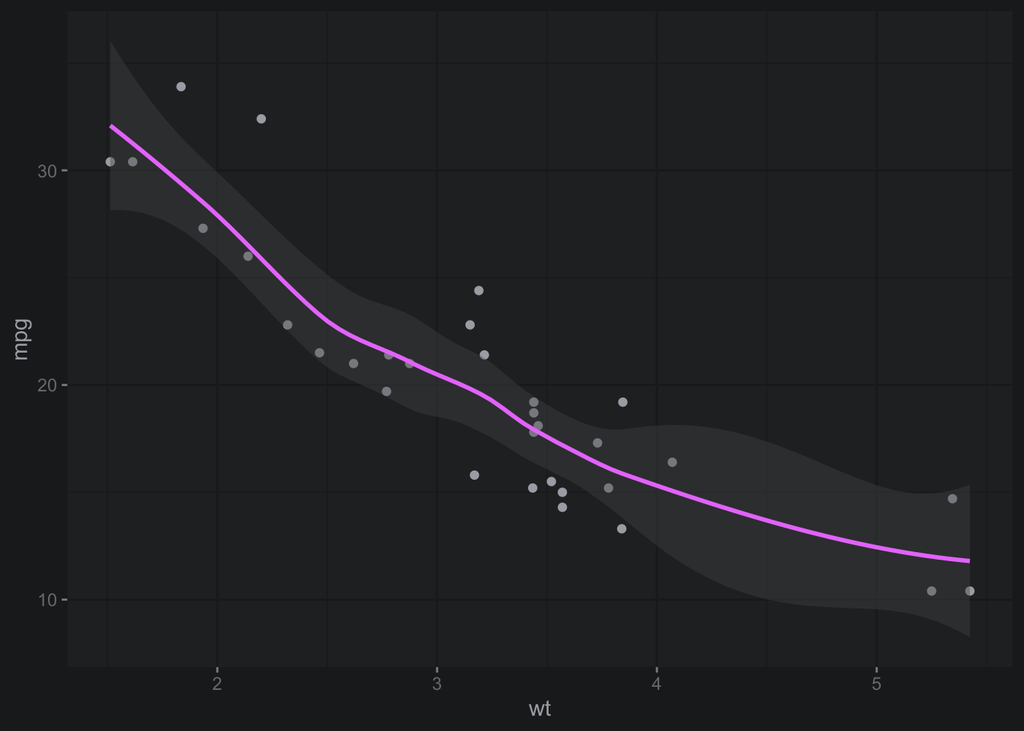

```r
library(ggplot2)

ggplot(mtcars, aes(wt, mpg)) +
  geom_point() + geom_smooth()
```

## 3.3 Create an RStudio project

RStudio gives you an option to start a project where you can:

- create a directory to store your data, analysis files, variables and the project related packages
- start the analysis from where you left it last time you worked on the project
- collaborate and publish reproducible analyses in public repositories such as github